# Stat 579 - Homework #5 - Section A

10/3/2019

## Another look at the Behavioral Risk Factor Surveillance System

We are, again, using the data from the Behavioral Risk Factor Surveillance System (BRFSS). Just as a reminder, the BRFSS surveys six individual-level behavioral health risk factors associated with the leading causes of premature mortality and morbidity among adults: 1) cigarette smoking, 2) alcohol use, 3) physical activity, 4) diet, 5) hypertension, and 6) safety belt use.

A subset of the data concentrating on Iowa with records for 2018 is given at

```r
library(tidyverse)
url <- "https://raw.githubusercontent.com/Stat579-at-ISU/stat579-at-isu.github.io/master/homework/data/brfss-iowa-2018.csv"
```

The following code reads the data into your R session:

```r
iowa <- read.csv(url)
```

A codebook describing the survey and a listing of all variables is available at https://www.cdc.gov/brfss/annual_data/2017/pdf/codebook17_llcp-v2-508.pdf.

For each of the questions, show the code necessary to retrieve the answer. Make sure to also write the answer to the question in a sentence.

1. Download the RMarkdown file with these homework instructions to use as a template for your work. Make sure to replace “Your Name” in the YAML with your name.
2. Load the dataset into your session and store it in the object `iowa`.
3. Check the codebook for an explanation of the variable `DRNK3GE5`. Do a frequency breakdown of the variable `DRNK3GE5` (visually or numerically). Comment.

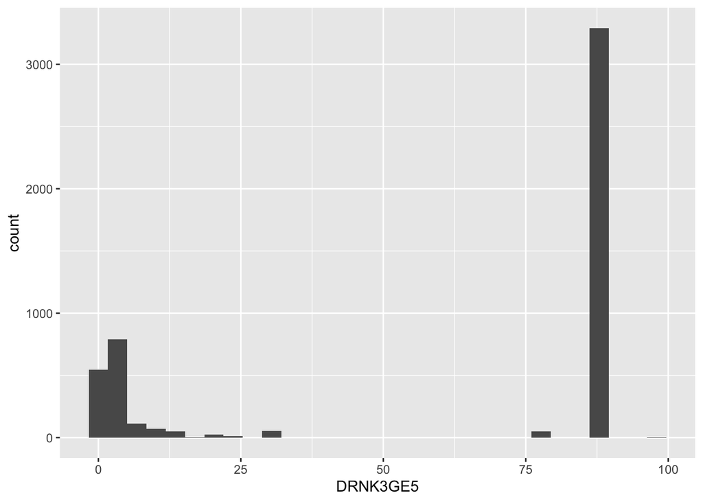

```r
iowa %>%
  ggplot(aes(x=DRNK3GE5)) +
  geom_histogram()
```

### Looking at this histogram, the largest group of people appear to have had 0 binge sessions in the last 30 days. This from the tall bar near the 88 value. A handful of NA values (from the short bar at around 77). For those who did binge drink (the part of the histogram between 1 and about 30), the distribution is pretty right skewed with outliers between around 16 and 30 binge drinking sessions.

Introduce a variable `bingedays` into the `iowa` data set that encodes 88 as 0, and 77 and 99 as `NA`.  
Find the following summaries:

```r
iowa <- iowa %>%
  mutate(bingedays = ifelse(between(DRNK3GE5, 1, 76), DRNK3GE5,
                        ifelse(DRNK3GE5 == 77, NA,
                               ifelse(DRNK3GE5 == 88, 0, NA))))
```

```
a. What is the average number of times respondents admitted to binge drinking in the past 30 days?
b. On how many reports is this average based (exclude missing values)?
c. Is there a difference in this average between the genders? Is that difference significant?
```

```r
mean(iowa$bingedays, na.rm=T)
```

```
## [1] 1.524127
```

```r
sum(!is.na(iowa$bingedays))
```

```
## [1] 4953
```

```r
aggregate(bingedays~SEX1, mean, data=iowa %>% filter(SEX1 %in% 1:2))
```

```
##   SEX1 bingedays
## 1    1 2.0598736
## 2    2 0.8893805
```

### a) The mean is 1.52 drinking sessions. b) This is from 4953 respondants. c) The mean for men is 2.06 and for women is 0.89.

4. Current smoking status is imputed in the variable `X_SMOKER3` (corresponds to variable `_SMOKER3` in the codebook). Make `X_SMOKER3` a factor. Relabel levels 1, 2, 3, 4 to `Current Smoker`, `Current Smoker`, `Former Smoker` and `Never Smoked` (yes, `Current Smoker` is repeated on purpose) and level 9 to NA. Describe the relationship between smoking status and age (use `X_AGE_G` - read up on `_AGE_G` in the codebook) based on an appropriate visualization.

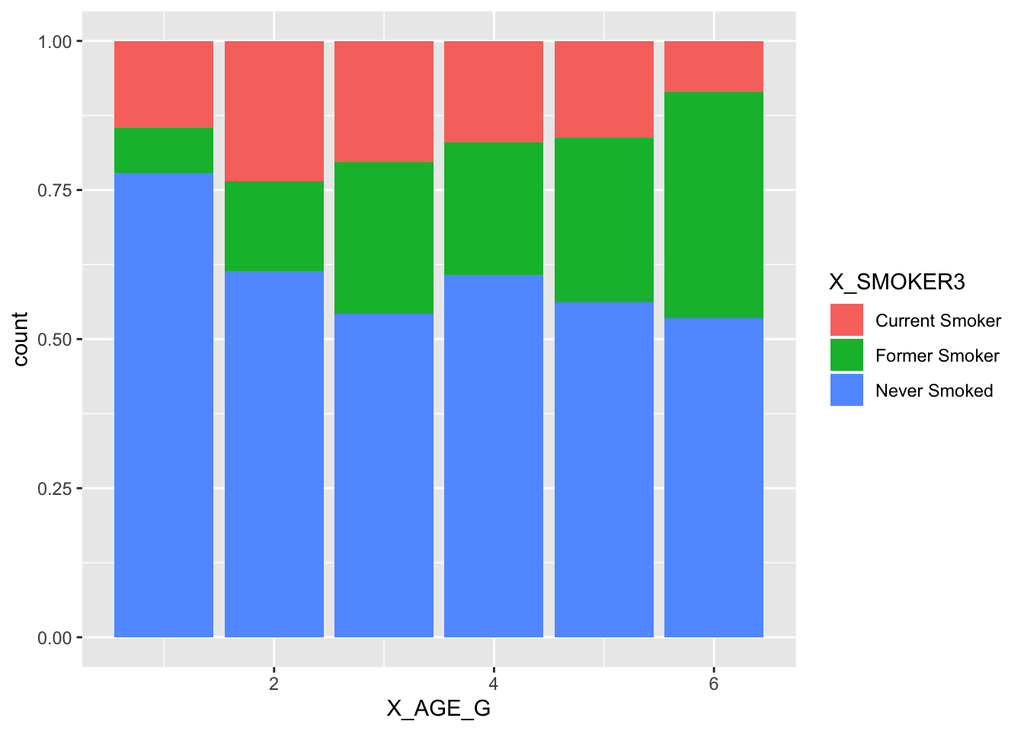

```r
labs <- c('Current Smoker', 'Current Smoker', 'Former Smoker', 'Never Smoked', NA)
iowa <- iowa %>%
  mutate(X_SMOKER3 = as.character(factor(X_SMOKER3, labels = labs)))

iowa %>%
  filter(!is.na(X_SMOKER3)) %>%
  ggplot(aes(x=X_AGE_G, fill=X_SMOKER3)) +
  geom_bar(position='fill')
```

### This bar chart shows that older generations tend to, but not in each age group, have slightly higher proportions of “Former Smokers” than previous generations. The younger generations tend to have more respondents who “Never Smoked” than the older generations.

5. What percentage of the population has never smoked? Calculate this percentage by age groups (`X_AGE_G`) and gender (`SEX1`). Report also on the number of respondents these percentages are based on (exclude any missing values).

```r
iowa %>%
  filter(!is.na(X_SMOKER3)) %>%
  filter(SEX1 %in% 1:2) %>%
  summarize(props = sum(X_SMOKER3 == "Never Smoked")/length(X_SMOKER3)*100)
```

```
##      props
## 1 57.91383
```

```r
iowa %>%
  filter(!is.na(X_SMOKER3)) %>%
  filter(SEX1 %in% 1:2) %>%
  group_by(X_AGE_G, SEX1) %>%
  summarize(props = sum(X_SMOKER3 == "Never Smoked")/length(X_SMOKER3)*100)
```

```
## # A tibble: 12 x 3
## # Groups:   X_AGE_G [6]
##    X_AGE_G  SEX1 props
##      <int> <int> <dbl>
##  1       1     1  76.1
##  2       1     2  80.9
##  3       2     1  53.2
##  4       2     2  70
##  5       3     1  47.2
##  6       3     2  60.5
##  7       4     1  56.1
##  8       4     2  64.9
##  9       5     1  50.8
## 10       5     2  61.3
## 11       6     1  41.8
## 12       6     2  62.2
```

### About 57.9% of the population has never smoked. The proportions for those who have never smoked by age and gender can be seen in the above table. Remember male = 1 and female = 2 and age increases as group number increases from 1 to 6.

6. Self assessed health status is used as an indicator in a lot of health and insurance models. Read up on variable `POORHLTH` in the codebook and recode levels to ‘meaningful’ numbers (similar to question 3). What is the relationship between age and the number of poor health days? Is this relationship different for men and women (`SEX1`)? Show plot(s) and describe.

```r
iowa <- iowa %>%
  mutate(poorhlth = ifelse(between(POORHLTH, 1, 30), POORHLTH,
                        ifelse(POORHLTH == 77, NA,
                               ifelse(POORHLTH == 88, 0, NA))))

iowa %>%
  filter(!is.na(poorhlth)) %>%
  filter(SEX1 %in% 1:2) %>%
  group_by(X_AGE_G) %>%
  summarize(means = mean(poorhlth))
```

```
## # A tibble: 6 x 2
##   X_AGE_G means
##     <int> <dbl>
## 1       1  2.79
## 2       2  2.86
## 3       3  3.11
## 4       4  4.33
## 5       5  5.23
## 6       6  4.74
```

```r
iowa %>%
  filter(!is.na(poorhlth)) %>%
  filter(SEX1 %in% 1:2) %>%
  group_by(X_AGE_G, SEX1) %>%
  summarize(means = mean(poorhlth))
```

```
## # A tibble: 12 x 3
## # Groups:   X_AGE_G [6]
##    X_AGE_G  SEX1 means
##      <int> <int> <dbl>
##  1       1     1  2.36
##  2       1     2  3.38
##  3       2     1  2.72
##  4       2     2  2.98
##  5       3     1  3.12
##  6       3     2  3.10
##  7       4     1  4.85
##  8       4     2  3.96
##  9       5     1  5.96
## 10       5     2  4.67
## 11       6     1  4.64
## 12       6     2  4.81
```

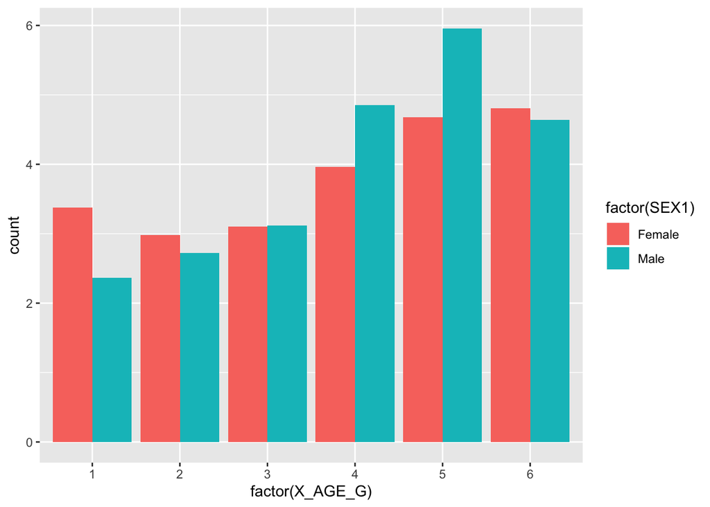

```r
iowa %>%
  filter(!is.na(poorhlth)) %>%
  filter(SEX1 %in% 1:2) %>%
  group_by(X_AGE_G, SEX1) %>%
  summarize(means = mean(poorhlth, na.rm=T)) %>%
  mutate(SEX1 = as.character(factor(SEX1, labels = c('Male', 'Female')))) %>%
  ggplot(aes(x=factor(X_AGE_G), weight=means, fill = factor(SEX1))) +
  geom_bar(position = 'dodge')
```

Due date: please refer to the website and Canvas for the due date.

For the submission: submit your solution in an R Markdown file and (just for insurance) submit the corresponding html/word file with it.